# Chapter 2. Time series models, trend and autocovariance

### Trend

Define the mean function (or trend) for $n \in 1: N$ by
$$\mu_{n}=\mathbb{E}\left[Y_{n}\right]=\int_{-\infty}^{\infty} y_{n} f_{Y_{n}}\left(y_{n}\right) d y_{n}$$
We only make observations at the discrete collection of times $t_{1:N}$ and so we require $\mu(t_n) = \mu_n$.

If the mean is constant, that is, $\mu_n = \mu$, the model is called **mean stationary**. We can estimate mean use the mean estimator, $\hat{\mu} = \hat{\mu}\left(y_{1: N}\right)=\frac{1}{N} \sum_{k=1}^{N} y_{k}$. It is only a reasonable estimator of the mean function when a mean stationary model is appropriate.

Trend is a property of the *model*, and the estimated trend is a function of the *data*.

### The autocovariance function

The covariance between two random variables $Y_m$ and $Y_n$
$$\gamma_{m, n}=\mathbb{E}\left[\left(Y_{m}-\mu_{m}\right)\left(Y_{n}-\mu_{n}\right)\right]$$
If the covariance between two observations **depends only on their time difference**, the time series model is **covariance stationary**. For observations equally spaced in time, the autocovariance function is then a function of a lag $h$, $\gamma_{h}=\gamma_{n, n+h}$.

For a covariance stationary model, a common *estimator* for $\gamma_h$ is
$$\hat{\gamma}_{h}\left(y_{1: N}\right)=\frac{1}{N} \sum_{n=1}^{N-h}\left(y_{n}-\hat{\mu}_{n}\right)\left(y_{n+h}-\hat{\mu}_{n+h}\right)$$
where $\hat{\mu}_{n}=\hat{\mu}_{n}\left(y_{1: N}\right)$ is a mean function estimator.

### The autocorrelation function

Dividing the autocovariance by the variance is the autocorrelation function $\rho_h$ given by
$$\rho_{h}=\frac{\gamma_{h}}{\gamma_{0}}$$
The standard autocorrelation estimator is given by $\hat{\rho}_{h}\left(y_{1: N}\right)=\frac{\hat{\gamma}_{h}\left(y_{1: N}\right)}{\hat{\gamma}_{0}\left(y_{1: N}\right)}$ and results in an estimate, the sample autocorrelation $\hat{\rho}_{h}=\hat{\rho}_{h}\left(y_{1: N}\right)=\frac{\hat{\gamma}_{h}}{\hat{\gamma}_{0}}$.

Note that **correlation** and **covariance** are properties of models. Sample autocorrelation and sample autocovariance are related to data.

```r
global_temp <- read.table("data/Global_Temperature.txt",header=TRUE)
str(global_temp)
```

```
## 'data.frame':    137 obs. of  3 variables:
##  $ Year            : int  1880 1881 1882 1883 1884 1885 1886 1887 1888 1889 ...
##  $ Annual          : num  -0.2 -0.12 -0.1 -0.21 -0.28 -0.32 -0.31 -0.33 -0.2 -0.12 ...
##  $ Moving5yrAverage: num  -0.13 -0.16 -0.19 -0.21 -0.24 -0.26 -0.27 -0.27 -0.27 -0.26 ...
```

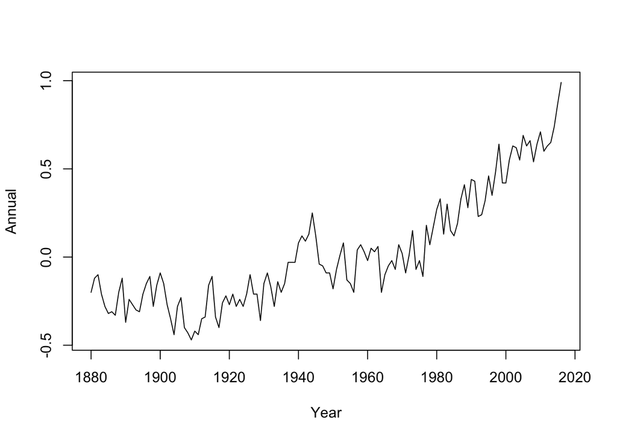

```r
plot(Annual~Year,data=global_temp,ty="l")
```

### Fitting a least squares model with a quadratic trend

```r
lm_fit <- lm(Annual~Year+I(Year^2),data=global_temp)
```

here `I()` is a function that tells R to construct `Year^2` as a variable, and inhibits interpretation in the R model formula notation.

```r
summary(lm_fit)
```

```
##
## Call:
## lm(formula = Annual ~ Year + I(Year^2), data = global_temp)
##
## Residuals:
##      Min       1Q   Median       3Q      Max
## -0.27092 -0.08638  0.00613  0.07481  0.38067
##
## Coefficients:
##               Estimate Std. Error t value Pr(>|t|)
## (Intercept)  2.959e+02  2.681e+01   11.04   <2e-16 ***
## Year        -3.111e-01  2.753e-02  -11.30   <2e-16 ***
## I(Year^2)    8.168e-05  7.067e-06   11.56   <2e-16 ***
## ---
## Signif. codes:  0 '***' 0.001 '**' 0.01 '*' 0.05 '.' 0.1 ' ' 1
##
## Residual standard error: 0.1157 on 134 degrees of freedom
## Multiple R-squared:  0.8766, Adjusted R-squared:  0.8748
## F-statistic: 476.1 on 2 and 134 DF,  p-value: < 2.2e-16
```

Check visually how well this model fits the data:

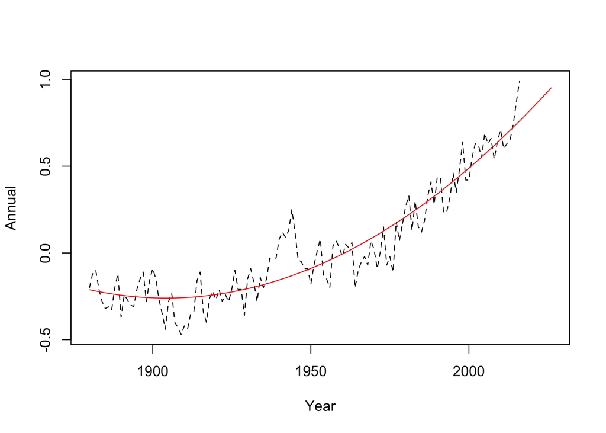

```r
yr <- 1880:2026
Z <- cbind(1,yr,yr^2)
beta <- coef(lm_fit)
prediction <- Z%*%beta
plot(Annual~Year,data=global_temp,ty="l",xlim=range(yr),
ylim=range(c(global_temp$Annual,prediction),na.rm=TRUE),
  lty="dashed")
lines(x=yr,y=prediction,col="red")
```

### White noise error model

The usual model behind OLS is the independent error model, known in time series analysis as the **white noise error model**.

A result for linear models is that $\hat{\beta}_{O L S}\left(y_{1: N}\right)$ is the minimum variance unbiased estimator for model $Y = Z\beta + \epsilon$, where $\epsilon = \epsilon_{1:N}$ is a vector of independent, identically distributed random variables with mean zero and constant variance,$\mathbb{E}\left[\epsilon_{n}\right]=0, \operatorname{Var}\left[\epsilon_{n}\right]=\sigma^{2}$.

`lm` in R, provides confidence intervals based on this model.

The variance/covariance matrix of $\hat{\beta}_{O L S}\left(Y_{1: N}\right)$ under this model is
$$\operatorname{Cov}\left[\hat{\beta}_{O L S}\left(Y_{1: N}\right)\right]=\sigma^{2}\left(Z^{\mathrm{T}} Z\right)^{-1}$$
and is estimated using an estimator for $\sigma$ by
$$\hat{\sigma}_{O L S}\left(y_{1: N}\right)=\sqrt{\frac{1}{N-d}\left(y-Z \hat{\beta}_{O L S}\right)^{\mathrm{T}}\left(y-Z \hat{\beta}_{O L S}\right)}$$
$d$ is the number of covariates, i.e., the number of columns of $Z$.

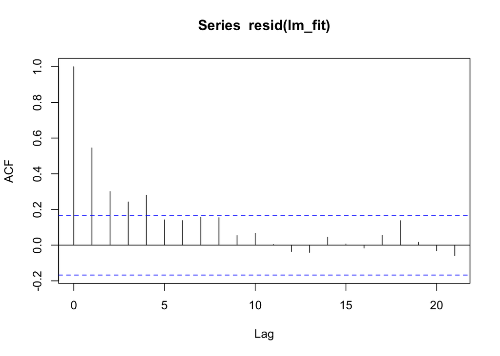

```r
acf(resid(lm_fit))
```

The *horizontal dashed lines* on the graph of the sample autocorrelation function (ACF) give **a measure of chance variation under the null hypothesis that the residuals are IID**.

At each lag h, the chance that the estimated ACF falls within this band is approximately $95\%$. Thus, under the null hypothesis, one expects a fraction of $1/20$ of the lags of the sample ACF to fall outside this band.

However, the sample ACF confirms what we can probably see from the plot of the fitted model: the variation around the fitted model is **clustered in time**, so the sample ACF of the residuals is not consistent with a model having independent error terms.

### Generalized least squares

If we know the covariance matrix, $\Gamma$, for a model with dependent errors,
$$Y=Z \beta+\zeta, \quad \zeta \sim N[0, \Gamma]$$
$\zeta$ follows a multivariate normal distribution with mean zero and covariance matrix $\Gamma$.

The minimum variance unbiased estimator of $\beta$ for this model is
$$\hat{\beta}_{G L S}\left(y_{1: N}\right)=\left(Z^{\mathrm{T}} \Gamma^{-1} Z\right)^{-1} Z^{\mathrm{T}} \Gamma^{-1} y$$
and the variance of $\beta$ is
$$\operatorname{Var}\left[\hat{\beta}_{O L S}\left(Y_{1: N}\right)\right]=\left(Z^{\mathrm{T}} Z\right)^{-1} Z^{\mathrm{T}} \Gamma Z\left(Z^{\mathrm{T}} Z\right)^{-1}$$

The OLS estimator remains unbiased for this model, but it’s often a practical solution to use the OLS estimator, expecially for preliminary data analysis. We can’t necessarily make a good estimator based on the GLS model *unless* we know $\Gamma$.

It is okay to do ordinary linear regression for data which are not well modeled with uncorrelated errors. However, if we do so, we should not trust the **error estimates** coming from $Y=Z\beta+\epsilon$ (where $\epsilon$ is treated as a white noise).